# Bike Share Case Study - 2 - Data Preparation

Let’s count the rows to be removed.

```r
bike_share %>%
  filter(ride_duration < 0) %>%
  nrow()
```

```
[1] 94
```

94 rows will be removed.

```r
bike_share <- bike_share %>%
  filter(ride_duration >= 0)
```

Let’s check the new row count.

```r
nrow(bike_share)
```

```
[1] 5594969
```

The new count is 5,594,969 as expected (5,595,063 - 94). Let’s verify that there are no more rides with negative duration.

```r
bike_share %>%
  filter(ride_duration < 0) %>%
  nrow()
```

```
[1] 0
```

The count is zero, as expected.

The rides that needed an hour added due to the time change raise an issue. Any ride that was in progress during the 1 a.m. hour on November 7 may have an incorrect duration. For example, a ride with a recorded start time of 01:15 and end time of 01:45 could have lasted 30 minutes or 90 minutes.

Let’s check for rides that started before 2:00 am on November 7 and ended on or after 1:00 am.

```r
bike_share %>%
  filter(
    started_at < ymd_hms("2021-11-07 02:00:00") &
    ended_at >= ymd_hms("2021-11-07 01:00:00")
  ) %>%
  nrow()
```

```
[1] 658
```

There are 658 rides that could have a duration which is an hour short, since an hour was possibly lost. We’ve already corrected the duration for 53 of them. But for many of them there’s no way to determine whether an hour needs to be added. Since the rides occurred in the early morning, it’s probably best to assume they were generally shorter rather than longer, and leave them as they are.

An alternative would be to add 30 minutes to such rides in an attempt to split the difference, but that might introduce more error than is already present.

However, any ride which started before 1 a.m. and ended at or after 2 a.m. definitely needs an hour added to the ride_duration. Let’s check how many of those rides there are.

```r
bike_share %>%
  filter(started_at < ymd_hms("2021-11-07 01:00:00") &
           ended_at >= ymd_hms("2021-11-07 02:00:00")
  ) %>%
  nrow()
```

```
[1] 31
```

There are only 31 such rides. We’ll add an hour to their durations.

First, we’ll store the filter criteria as a variable.

```r
rides_to_add_3600 <-
  bike_share$started_at < ymd_hms("2021-11-07 01:00:00") &
  bike_share$ended_at >= ymd_hms("2021-11-07 02:00:00")
```

Now we’ll add an hour to those rides.

```r
bike_share <- bike_share %>%
  mutate(ride_duration = ifelse(
                           rides_to_add_3600,
                           ride_duration + 3600,
                           ride_duration
                         )
  )
```

We should also correct any rides that had an hour added on March 14, when Daylight Saving Time began at 2:00 am.

Let’s count them.

```r
rides_to_subtract_3600 <-
  bike_share$started_at < ymd_hms("2021-03-14 02:00:00") &
  bike_share$ended_at >= ymd_hms("2021-03-14 03:00:00")

bike_share %>%
  filter(rides_to_subtract_3600) %>%
  nrow()
```

```
[1] 77
```

We’ll subtract an hour from these 77 rides.

```r
bike_share <- bike_share %>%
  mutate(ride_duration = ifelse(
                           rides_to_subtract_3600,
                           ride_duration - 3600,
                           ride_duration
                         )
  )
```

Let’s make sure we didn’t inadvertently create any negative values.

```r
bike_share %>%
  filter(ride_duration < 0) %>%
  nrow()
```

```
[1] 0
```

The count is zero, as expected.

Let’s look at rides that last more than 1 day (24 * 3600 seconds).

```r
bike_share %>%
  filter(ride_duration > 24 * 3600) %>%
  nrow()
```

```
[1] 4029
```

For these 4029 rides we’ll make a histogram with bin width of one day, and we’ll facet by bike type. We’ll convert to days and use a bin width of 1.

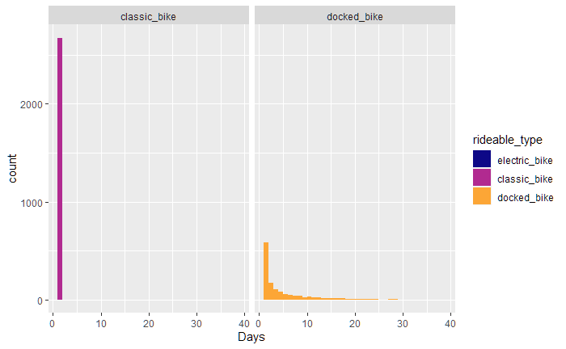

```r
bike_share %>%
  filter(ride_duration > 24 * 3600) %>%
  ggplot(mapping = aes(x = ride_duration / 3600 / 24, fill = rideable_type)) +
  geom_histogram(binwidth = 1, boundary = 0, closed = "left") +
  scale_fill_viridis_d(option = "plasma", end = 0.8, drop = FALSE) +
  xlab(label = "Days") +
  facet_wrap(~ rideable_type)
```

It looks like classic bike rides last no more than two days, electric bike rides last no more than one day. Only the docked bikes have rides lasting more than two days.

Let’s check whether these rides are associated with any specific time period. We’ll split them into six categories by ride duration, and look at the monthly counts of each category.

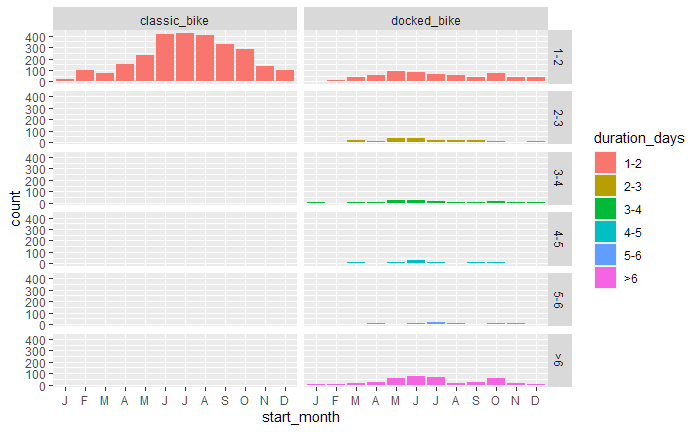

```r
long_ride_cut <- 3600 * 24 * c(1:6, 50)
long_ride_labels <- c("1-2", "2-3", "3-4", "4-5", "5-6", ">6")

bike_share %>%
  filter(ride_duration > 3600 * 24) %>%
  mutate(duration_days =
           cut(ride_duration, breaks = long_ride_cut, labels = long_ride_labels)           ) %>%
  ggplot(mapping = aes(x = start_month)) +
  geom_bar(mapping = aes(fill = duration_days)) +
  scale_x_discrete(labels = substr(levels(bike_share$start_month), 1, 1)) +
  facet_grid(duration_days ~ rideable_type)
```

The rides of various durations seem to be distributed as rides are in general, but there’s an unexpected peak in October of rides that last more than 6 days.

Let’s look more closely at the time distribution of rides that took more than three days. We’ll plot the counts through time, and use color to indicate day of the week.

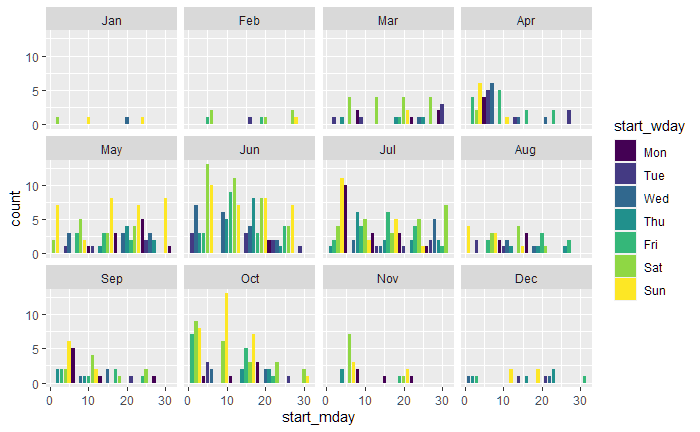

```r
bike_share %>%
  filter(ride_duration > 3 * 24 * 3600) %>%
  ggplot(mapping = aes(x = start_mday)) +
  geom_bar(mapping = aes(fill = start_wday)) +
  facet_wrap(~ start_month)
```

There does appear to be an unexpected increase in long rides in October, but they’re correlated with the weekends. Maybe there was very good weather. Without access to further information, it’s best to keep them in the data set. We’ll make a note of this finding in the data summary.

Let’s look at rides that last more than an hour, but no more than two days.

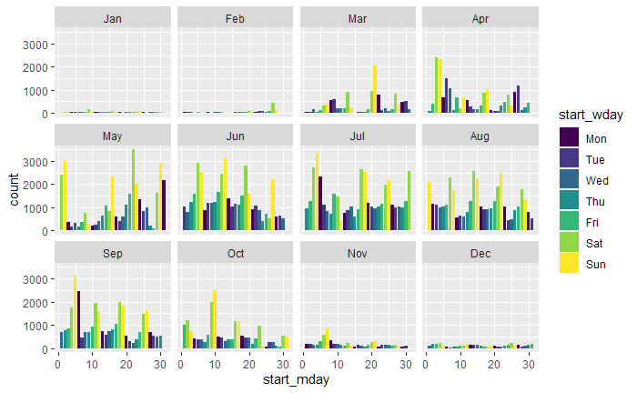

```r
bike_share %>%
  filter(ride_duration > 3600 & ride_duration <= 48 * 3600 ) %>%
  ggplot(mapping = aes(x = start_mday)) +
  geom_bar(mapping = aes(fill = start_wday)) +
  facet_wrap(~ start_month)
```

The rides look well distributed, with peaks on weekends and holidays.

Let’s look at rides that last no more than an hour. We’ll use a bin width of one minute.

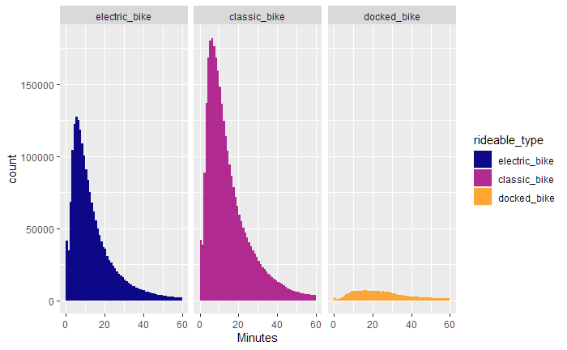

```r
bike_share %>%
  filter(ride_duration <= 3600) %>%
  ggplot(mapping = aes(x = ride_duration / 60, fill = rideable_type)) +
  geom_histogram(binwidth = 1, boundary = 0, closed = "left") +
  xlab(label = "Minutes") +
  scale_fill_viridis_d(option = "plasma", end = 0.8, drop = FALSE) +
  facet_wrap(~ rideable_type)
```

For electric and classic bikes, the peak is around six to eight minutes, with a smooth fall afterwards. For docked bikes there’s not a sharp peak, and the rides tend to last ten to thirty minutes.

We’ll also look at their distribution in time.

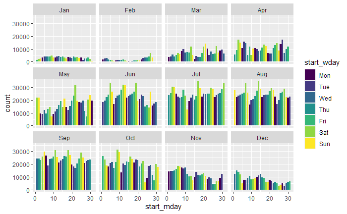

```r
bike_share %>%
  filter(ride_duration <= 3600) %>%
  ggplot(mapping = aes(x = start_mday)) +
  geom_bar(mapping = aes(fill = start_wday)) +
  facet_wrap(~ start_month)
```

There’s nothing unusual in the distribution.

We should check for rides that have zero duration.

```r
bike_share %>%
  filter(ride_duration == 0) %>%
  group_by(rideable_type) %>%
  count()
```

| rideable_type | n |
| --- | --- |
| electric_bike | 306 |
| classic_bike | 197 |
| docked_bike | 3 |

They’re nearly all for electric or classic bikes. Let’s check the distribution in time of these 506 rides.

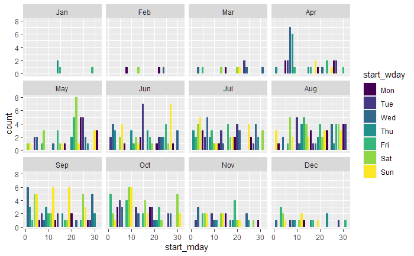

```r
bike_share %>%
  filter(ride_duration == 0) %>%
  ggplot(mapping = aes(x = start_mday)) +
  geom_bar(mapping = aes(fill = start_wday)) +
  facet_wrap(~ start_month)
```

These rides look well distributed in time.

Let’s look at rides that have a duration in the range 1 to 60 seconds.

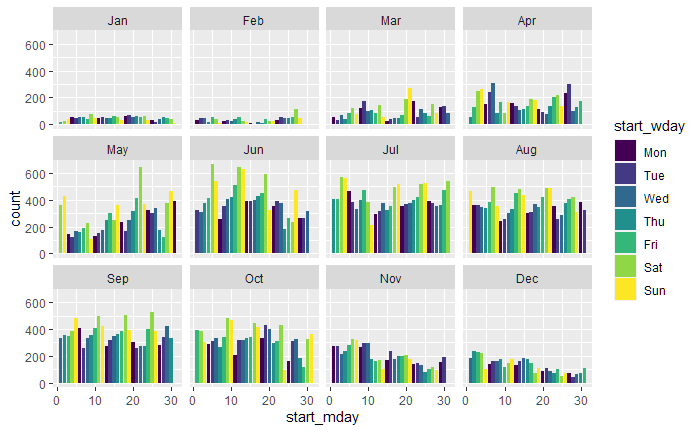

```r
bike_share %>%
  filter(between(ride_duration, left = 1, right = 60)) %>%
  ggplot(mapping = aes(x = start_mday)) +
  geom_bar(mapping = aes(fill = start_wday)) +
  facet_wrap(~ start_month)
```

These rides also look well distributed. It’s not clear why a ride lasts less than a minute. Let’s check the number of these rides.

```r
bike_share %>%
  filter(between(ride_duration, left = 1, right = 60)) %>%
  group_by(rideable_type) %>%
  count()
```

| rideable_type | n |
| --- | --- |
| electric_bike | 41384 |
| classic_bike | 42107 |
| docked_bike | 1967 |

There are 85,458 such rides. Let’s check how many of these rides have both a start station name and an end station name.

```r
bike_share %>%
  filter(between(ride_duration, left = 1, right = 60)) %>%
  filter(!is.na(start_station_name) & !is.na(end_station_name)) %>%
  nrow()
```

```
[1] 59813
```

Let’s check how many of these 59,813 rides end at a different station than the start station.

```r
bike_share %>%
  filter(between(ride_duration, left = 1, right = 60)) %>%
  filter(!is.na(start_station_name) & !is.na(end_station_name)) %>%
  filter(start_station_name != end_station_name) %>%
  nrow()
```

```
[1] 1571
```

Only 1,571 of these rides ended at a different station from where they started. We would need more information about user behavior to justify removing very short rides, but we’ll need to consider their presence when doing further analysis. There are 85,964 rides of a minute or less, which is about 1.5% of the total 5,594,969 rides. Of those rides, 506 have zero duration.

Let’s look at median ride duration for each bike type, by month.

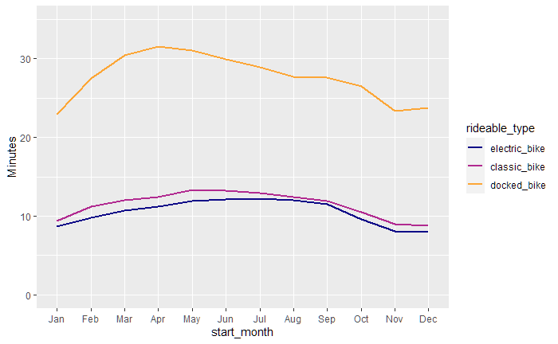

```r
bike_share %>%
  group_by(rideable_type, start_month) %>%
  summarize(med_dur = median(ride_duration / 60), .groups = "keep") %>%
  ggplot(mapping = aes(x = start_month, y = med_dur, group = rideable_type)) +
  geom_line(mapping = aes(color = rideable_type), size = 1) +
  scale_color_viridis_d(option = "plasma", end = 0.8, drop = FALSE) +
  ylab(label = "Minutes") +
  coord_cartesian(ylim = c(0, 35))
```

We see that the monthly median duration of docked bike rides is over twice that of the other bike types. Also, the monthly median duration of docked bike rides peaked around April, and then generally declined the rest of the year. The monthly median durations for the other two types of bikes peaked between May and August, with median duration of classic bikes always slightly higher than for electric bikes.

Let’s look at median ride duration for each bike type, by day of the week.

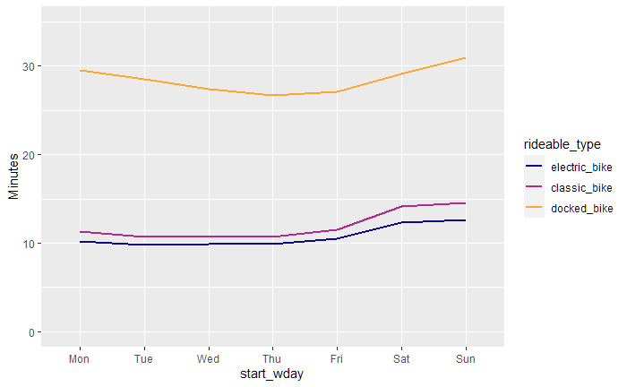

```r
bike_share %>%
  group_by(rideable_type, start_wday) %>%
  summarize(med_dur = median(ride_duration / 60), .groups = "keep") %>%
  ggplot(mapping = aes(x = start_wday, y = med_dur, group = rideable_type)) +
  geom_line(mapping = aes(color = rideable_type), size = 1) +
  scale_color_viridis_d(option = "plasma", end = 0.8, drop = FALSE) +
  ylab(label = "Minutes") +
  coord_cartesian(ylim = c(0, 35))
```

For electric and classic bikes, median weekday ride duration increases by three or four minutes on weekends. For docked bikes the median decreases by three or four minutes from Monday to Thursday, then climbs back to a median near 30 minutes on Sunday.

Let’s look at median ride duration for each bike type, by hour of the day.

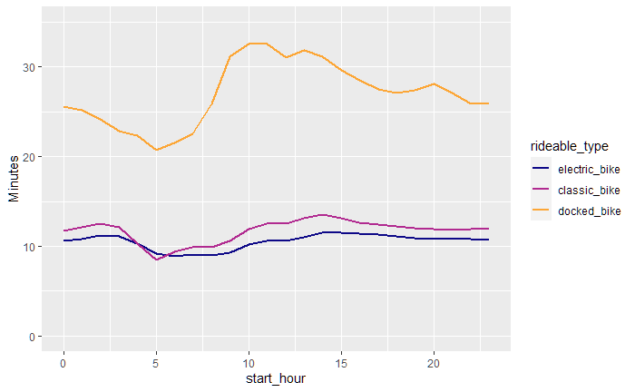

```r
bike_share %>%
  group_by(rideable_type, start_hour) %>%
  summarize(med_dur = median(ride_duration / 60), .groups = "keep") %>%
  ggplot(mapping = aes(x = start_hour, y = med_dur, group = rideable_type)) +
  geom_line(mapping = aes(color = rideable_type), size = 1) +
  scale_color_viridis_d(option = "plasma", end = 0.8, drop = FALSE) +
  ylab(label = "Minutes") +
  coord_cartesian(ylim = c(0, 35))
```

For electric bikes, the median hourly ride duration stays between 8 and 12 minutes throughout the day. For classic bikes it ranges from 8 to 14 minutes throughout the day, with a dip between 4 a.m. and 9 a.m., but otherwise fairly steady values in the 12 to 14 minute range. For docked bikes, it ranges from 20 to 33 minutes, with the highest values between 9 a.m. and 3 p.m. and a gradual decline through the evening and early morning to a low at 5 a.m.

### Exploring - station names and IDs

Now let’s take a look at the station names and IDs.

Let’s see how many distinct station names and IDs there are. First we’ll make a table of all combinations of start station names and IDs.

```r
start_stations <- bike_share %>%
  distinct(start_station_name, start_station_id) %>%
  rename(name = start_station_name, id = start_station_id)

start_stations
```

| name | id |
| --- | --- |
| California Ave & Cortez St | 17660 |
| Halsted St & North Branch St | KA1504000117 |
| Glenwood Ave & Touhy Ave | 525 |
| Michigan Ave & 8th St | 623 |
| Shedd Aquarium | 15544 |
| Sedgwick St & North Ave | TA1307000038 |
| Rush St & Hubbard St | KA1503000044 |
| Campbell Ave & Montrose Ave | 15623 |
| State St & Harrison St | SL-007 |
| Sheffield Ave & Fullerton Ave | TA1306000016 |

[output cut: 842 more lines]

We’ll do the same for end station names and IDs.

```r
end_stations <- bike_share %>%
  distinct(end_station_name, end_station_id) %>%
  rename(name = end_station_name, id = end_station_id)

end_stations
```

| name | id |
| --- | --- |
| NA | NA |
| Wood St & Augusta Blvd | 657 |
| California Ave & North Ave | 13258 |
| Wells St & Elm St | KA1504000135 |
| Sacramento Blvd & Franklin Blvd | KA1504000113 |
| Western Ave & Walton St | KA1504000103 |
| Damen Ave & Clybourn Ave | 13271 |
| Leavitt St & North Ave | TA1308000005 |
| Honore St & Division St | TA1305000034 |
| Ogden Ave & Chicago Ave | TA1305000020 |

[output cut: 836 more lines]

Now we’ll join these tables together, remove duplicates, and arrange by ID.

```r
stations <- rbind(start_stations, end_stations) %>%
  distinct(name, id) %>%
  arrange(id)

stations
```

| name | id |
| --- | --- |
| Michigan Ave & Washington St | 13001 |
| LaSalle St & Washington St | 13006 |
| Millennium Park | 13008 |
| Canal St & Adams St | 13011 |
| St. Clair St & Erie St | 13016 |
| Franklin St & Chicago Ave | 13017 |
| Clinton St & Lake St | 13021 |
| Streeter Dr & Grand Ave | 13022 |
| 900 W Harrison St | 13028 |
| Field Museum | 13029 |

[output cut: 842 more lines]

We’ll check for any NA values.

```r
stations %>%
  filter(is.na(name) | is.na(id))
```

| name | id |
| --- | --- |
| NA | 13221 |
| NA | 20215 |
| NA | WL-008 |
| NA | NA |

Whenever the station ID is NA, so is the station name. Let’s look for station names for the IDs 13221, 20215, and WL-008.

```r
stations %>%
  filter(id %in% c("13221", "20215", "WL-008"))
```

| name | id |
| --- | --- |
| Wood St & Milwaukee Ave | 13221 |
| NA | 13221 |
| Hegewisch Metra Station | 20215 |
| NA | 20215 |
| Clinton St & Roosevelt Rd | WL-008 |
| NA | WL-008 |

We will correct the missing names in the data set for these station IDs.

```r
bike_share <- bike_share %>%
  mutate(start_station_name =
           ifelse(
             is.na(start_station_name) & start_station_id == "13221",
             "Wood St & Milwaukee Ave",
             start_station_name
           )
  ) %>%
  mutate(end_station_name =
           ifelse(
             is.na(end_station_name) & end_station_id == "13221",
             "Wood St & Milwaukee Ave",
             end_station_name
           )
  ) %>%
  mutate(start_station_name =
           ifelse(
             is.na(start_station_name) & start_station_id == "20215",
             "Hegewisch Metra Station",
             start_station_name
           )
  ) %>%
  mutate(end_station_name =
           ifelse(
             is.na(end_station_name) & end_station_id == "20215",
             "Hegewisch Metra Station",
             end_station_name
           )
  ) %>%
  mutate(start_station_name =
           ifelse(
             is.na(start_station_name) & start_station_id == "WL-008",
             "Clinton St & Roosevelt Rd",
             start_station_name
           )
  ) %>%
  mutate(end_station_name =
           ifelse(
             is.na(end_station_name) & end_station_id == "WL-008",
             "Clinton St & Roosevelt Rd",
             end_station_name
           )
  )
```

Let’s make sure it was done correctly. We’ll check whether there are any station names missing for these IDs.

```r
bike_share %>%
  filter(start_station_id %in% c("13221", "20215", "WL-008")) %>%
  distinct(start_station_name, start_station_id) %>%
  arrange(start_station_id)
```

| start_station_name | start_station_id |
| --- | --- |
| Wood St & Milwaukee Ave | 13221 |
| Hegewisch Metra Station | 20215 |
| Clinton St & Roosevelt Rd | WL-008 |

```r
bike_share %>%
  filter(end_station_id %in% c("13221", "20215", "WL-008")) %>%
  distinct(end_station_name, end_station_id) %>%
  arrange(end_station_id)
```

| end_station_name | end_station_id |
| --- | --- |
| Wood St & Milwaukee Ave | 13221 |
| Hegewisch Metra Station | 20215 |
| Clinton St & Roosevelt Rd | WL-008 |

Records with these station IDs now have the correct station name. Let’s make sure no other station names were inadvertently changed. We’ll make sure the three station names are only used with those IDs.

```r
three_names_to_check <- c("Wood St & Milwaukee Ave",
                          "Hegewisch Metra Station",
                          "Clinton St & Roosevelt Rd"
                        )

bike_share %>%
  filter(start_station_name %in% three_names_to_check) %>%
  distinct(start_station_name, start_station_id) %>%
  arrange(start_station_id)
```

| start_station_name | start_station_id |
| --- | --- |
| Wood St & Milwaukee Ave | 13221 |
| Hegewisch Metra Station | 20215 |
| Clinton St & Roosevelt Rd | WL-008 |

```r
bike_share %>%
  filter(end_station_name %in% three_names_to_check) %>%
  distinct(end_station_name, end_station_id) %>%
  arrange(end_station_id)
```

| end_station_name | end_station_id |
| --- | --- |
| Wood St & Milwaukee Ave | 13221 |
| Hegewisch Metra Station | 20215 |
| Clinton St & Roosevelt Rd | WL-008 |

The changes were made correctly. Now a station name should be NA if and only if the station ID is NA. Let’s verify that.

```r
bike_share %>%
  filter(is.na(start_station_name) | is.na(start_station_id)) %>%
  distinct(start_station_name, start_station_id)
```

| start_station_name | start_station_id |
| --- | --- |
| NA | NA |

```r
bike_share %>%
  filter(is.na(end_station_name) | is.na(end_station_id)) %>%
  distinct(end_station_name, end_station_id)
```

| end_station_name | end_station_id |
| --- | --- |
| NA | NA |

Now stations with missing names always have missing IDs, and vice versa.

Let’s check whether each station name has a unique station ID.

```r
stations %>%
  filter(!is.na(name)) %>%
  group_by(name) %>%
  mutate(count = n()) %>%
  filter(count > 1) %>%
  arrange(name)
```

| name | id | count |
| --- | --- | --- |
| Loomis St & 89th St | 20102 | 2 |
| Loomis St & 89th St | 201022 | 2 |

The station Loomis St and 89th has two IDs. Let’s figure out which is the correct ID. We’ll plot the ride counts for this station name by week, using color to distinguish the station IDs. We’ll look at both the start and end stations.

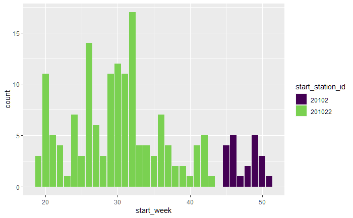

```r
loomis <- "Loomis St & 89th St"

bike_share %>%
  filter(start_station_name == loomis) %>%
  ggplot(mapping = aes(x = start_week)) +
  geom_bar(mapping = aes(fill = start_station_id)) +
  scale_fill_viridis_d(end = 0.8)
```

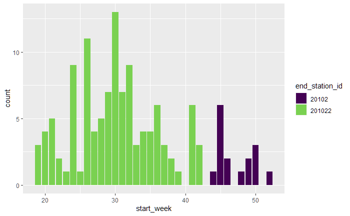

```r
bike_share %>%
  filter(end_station_name == loomis) %>%
  ggplot(mapping = aes(x = start_week)) +
  geom_bar(mapping = aes(fill = end_station_id)) +
  scale_fill_viridis_d(end = 0.8)
```

20102 is the most recent ID for this station, so we’ll convert any IDs for this station name from 201022 to 20102.

```r
bike_share <- bike_share %>%
  mutate(start_station_id =
           ifelse(
             start_station_name == loomis & start_station_id == "201022",
             "20102",
             start_station_id
           )
  ) %>%
  mutate(end_station_id =
           ifelse(
             end_station_name == loomis & end_station_id == "201022",
             "20102",
             end_station_id
           )
  )
```

We can run the graphs again to check that the IDs are now correct.

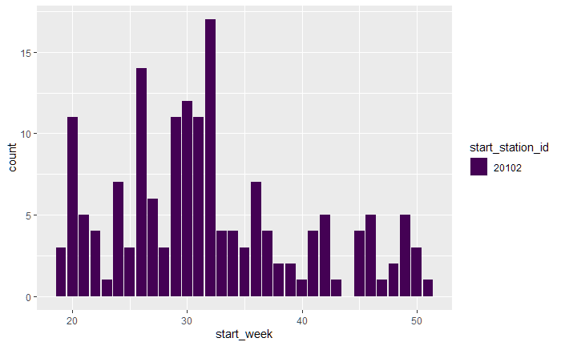

```r
bike_share %>%
  filter(start_station_name == loomis) %>%
  ggplot(mapping = aes(x = start_week)) +
  geom_bar(mapping = aes(fill = start_station_id)) +
  scale_fill_viridis_d(end = 0.8)
```

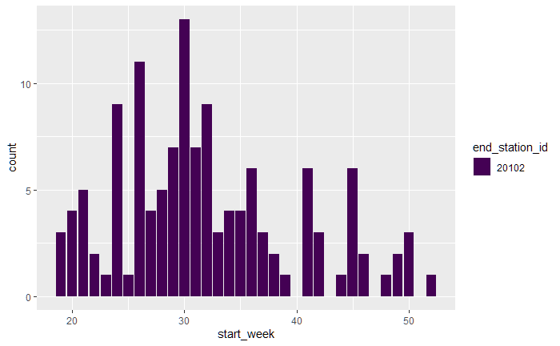

```r
bike_share %>%
  filter(end_station_name == loomis) %>%
  ggplot(mapping = aes(x = start_week)) +
  geom_bar(mapping = aes(fill = end_station_id)) +
  scale_fill_viridis_d(end = 0.8)
```

Let’s verify that only the Loomis station has the ID 20102, and that ID 201022 is no longer present in the data set.

```r
bike_share %>%
  filter(start_station_id == "20102" | start_station_id == "201022") %>%
  distinct(start_station_name, start_station_id) %>%
  arrange(start_station_id)
```

| start_station_name | start_station_id |
| --- | --- |
| Loomis St & 89th St | 20102 |

```r
bike_share %>%
  filter(end_station_id == "20102" | start_station_id == "201022") %>%
  distinct(end_station_name, end_station_id) %>%
  arrange(end_station_id)
```

| end_station_name | end_station_id |
| --- | --- |
| Loomis St & 89th St | 20102 |

The changes were made correctly.

Now if we group the data by station names, only one station ID should be associated with each name. Let’s verify that.

```r
bike_share %>%
  distinct(start_station_name, start_station_id) %>%
  group_by(start_station_name) %>%
  mutate(count = n()) %>%
  filter(count > 1) %>%
  nrow()
```

```
[1] 0
```

```r
bike_share %>%
  distinct(end_station_name, end_station_id) %>%
  group_by(end_station_name) %>%
  mutate(count = n()) %>%
  filter(count > 1) %>%
  nrow()
```

```
[1] 0
```

We found no examples of a station name associated with more than one ID. Let’s check whether each ID is associated with only one name.

```r
stations %>%
  filter(!is.na(name)) %>%
  group_by(id) %>%
  mutate(count = n()) %>%
  filter(count > 1) %>%
  arrange(id)  %>%
  print(n = Inf)
```

| name | id | count |
| --- | --- | --- |
| Broadway & Wilson Ave | 13074 | 2 |
| Broadway & Wilson - Truman College Vaccination Site | 13074 | 2 |
| Halsted St & 18th St | 13099 | 2 |
| Halsted St & 18th St (Temp) | 13099 | 2 |
| Lake Shore Dr & Monroe St | 13300 | 2 |
| DuSable Lake Shore Dr & Monroe St | 13300 | 2 |
| Mulligan Ave & Wellington Ave | 351 | 2 |
| 351 | 351 | 2 |
| Malcolm X College | 631 | 2 |
| Malcolm X College Vaccination Site | 631 | 2 |

[output cut: 17 more lines]

There are 13 station IDs that have more than one station name. Let’s store those IDs in a vector.

```r
ids_with_mult_names <- stations %>%
  filter(!is.na(name)) %>%
  group_by(id) %>%
  mutate(count = n()) %>%
  filter(count > 1) %>%
  select(id) %>%
  distinct %>%
  arrange(id) %>%
  pull()

ids_with_mult_names
```

```
 [1] "13074"        "13099"        "13300"        "351"          "631"
 [6] "KA1503000055" "KA1504000168" "LF-005"       "TA1305000039" "TA1306000029"
[11] "TA1307000041" "TA1309000039" "TA1309000049"
```

Now let’s plot counts of rides that started at each of these stations. We’ll divide them into four groups and plot ride counts by week, using color to indicate the different station names.

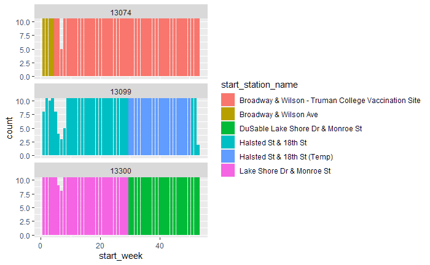

```r
bike_share %>%
  filter(start_station_id %in% ids_with_mult_names[1:3]) %>%
  ggplot(mapping = aes(x = start_week)) +
  geom_bar(mapping = aes(fill = start_station_name)) +
  coord_cartesian(ylim = c(0, 10)) +
  facet_wrap(~ start_station_id, nrow = 3)
```

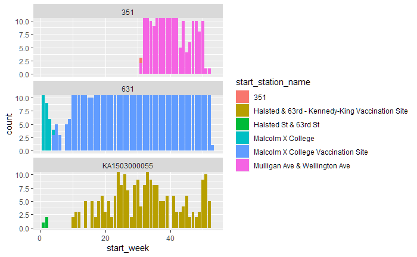

```r
bike_share %>%
  filter(start_station_id %in% ids_with_mult_names[4:6]) %>%
  ggplot(mapping = aes(x = start_week)) +
  geom_bar(mapping = aes(fill = start_station_name)) +
  coord_cartesian(ylim = c(0, 10)) +
  facet_wrap(~ start_station_id, nrow = 3)
```

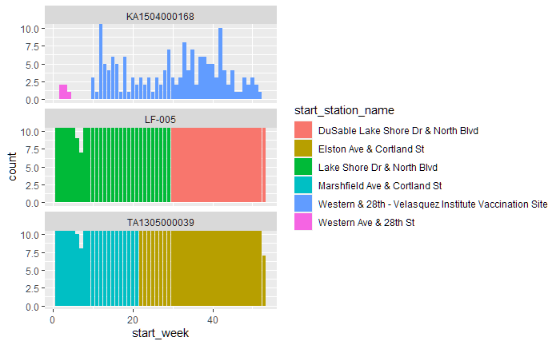

```r
bike_share %>%
  filter(start_station_id %in% ids_with_mult_names[7:9]) %>%
  ggplot(mapping = aes(x = start_week)) +
  geom_bar(mapping = aes(fill = start_station_name)) +
  coord_cartesian(ylim = c(0, 10)) +
  facet_wrap(~ start_station_id, nrow = 3)
```

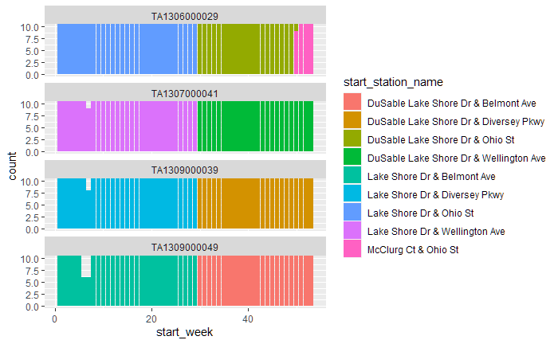

```r
bike_share %>%
  filter(start_station_id %in% ids_with_mult_names[10:13]) %>%
  ggplot(mapping = aes(x = start_week)) +
  geom_bar(mapping = aes(fill = start_station_name)) +
  coord_cartesian(ylim = c(0, 10)) +
  facet_wrap(~ start_station_id, nrow = 4)
```

In each case, it’s clear that the station’s name was changed at some point during the year, and that station IDs aren’t being used for more than one station at a time.

We’ll use the station IDs, and won’t try to correct station names for now. If we need to use station names later, the names can be corrected at that time.

Let’s look at the list of station names and IDs.

```r
stations %>%
  arrange(name) %>%
  print(n = Inf)
```

| name | id |
| --- | --- |
| 2112 W Peterson Ave | KA1504000155 |
| 351 | 351 |
| 63rd St Beach | 15491 |
| 900 W Harrison St | 13028 |
| Aberdeen St & Jackson Blvd | 13157 |
| Aberdeen St & Monroe St | 13156 |
| Aberdeen St & Randolph St | 18062 |
| Ada St & 113th St | 20129 |
| Ada St & Washington Blvd | 13353 |
| Adler Planetarium | 13431 |

[output cut: 842 more lines]

The station ID “Hubbard Bike-checking (LBS-WH-TEST)” looks like it may be for testing purposes only. We’re going to make that assumption and remove the rides associated with that station ID from the data set.

First, let’s count the rides.

```r
test_station <- "Hubbard Bike-checking (LBS-WH-TEST)"

bike_share %>%
  filter(start_station_id == test_station | end_station_id == test_station) %>%
  nrow()
```

```
[1] 876
```

There are 876 rides with associated with this station ID.

Removing them is a little tricky because the dplyr filter() function will drop rows for which the condition returns a value of NA. We want to avoid inadvertently removing rows with missing station IDs.

```r
bike_share <- bike_share %>%
  filter(start_station_id != test_station | is.na(start_station_id)) %>%
  filter(end_station_id   != test_station | is.na(end_station_id))
```

Now we’ll check the number of rows left in the data set.

```r
nrow(bike_share)
```

```
[1] 5594093
```

There are 5,594,093 rows, as expected (5,594,969 - 876).

Let’s check whether stations are being added or removed over time. For each station, we’ll get the minimum and maximum months in which a ride began at the station. Then we’ll remove stations that had January as the minimum and December as the maximum month. For each month, we’ll plot the number of stations that had the first ride in that month, and use color to indicate the month of the most recent ride.

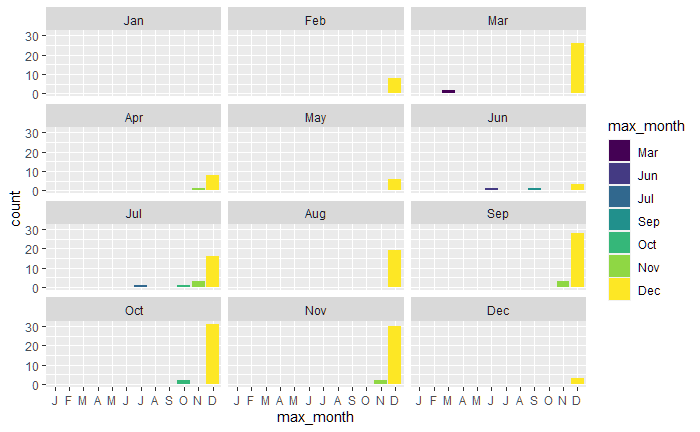

```r
bike_share %>%
  filter(!is.na(start_station_id)) %>%
  group_by(start_station_id) %>%
  summarize(
    min_month = min(start_month),
    max_month = max(start_month),
  )  %>%
  filter(!(min_month == "Jan" & max_month == "Dec")) %>%
  ggplot(mapping = aes(x = max_month)) +
  geom_bar(mapping = aes(fill = max_month)) +
  scale_x_discrete(
    breaks = levels(bike_share$start_month),
    drop = FALSE,
    labels = substr(levels(bike_share$start_month), 1, 1)
  ) +
  facet_wrap(~ min_month, nrow = 4, drop = FALSE)
```

For example, the plot shows there are about 20 station IDs at which no ride started until July. Most of those stations (the ones in yellow) were still in use in December, but a few were last used in July, October, or November.

We see that there are over 100 station IDs that weren’t in use before August. And there are a few stations that were only in use for a limited time. So we have to be careful using the station data because many new stations were added (and some possibly removed) throughout the year.

Let’s take a look at monthly counts of rides with and without start station information.

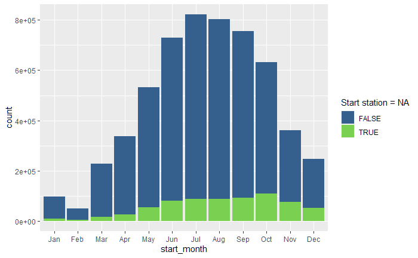

```r
bike_share %>%
  ggplot(mapping = aes(x = start_month)) +
  geom_bar(mapping = aes(fill = is.na(start_station_id))) +
  scale_fill_viridis_d(
    begin = 0.3,
    end = 0.8,
    guide = guide_legend(title = "Start station = NA")
  )
```

It looks like the proportion of rides without station information increased over time. Let’s check that for start and end stations.

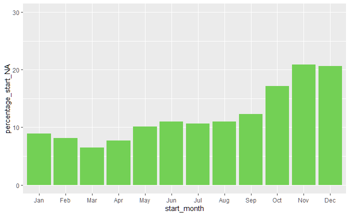

```r
bike_share %>%
  group_by(start_month) %>%
  summarize(percentage_start_NA = 100 * mean(is.na(start_station_id))) %>%
  ggplot(mapping = aes(x = start_month, y = percentage_start_NA)) +
  geom_col(fill = "#73D055FF") +
  coord_cartesian(ylim = c(0, 30))
```

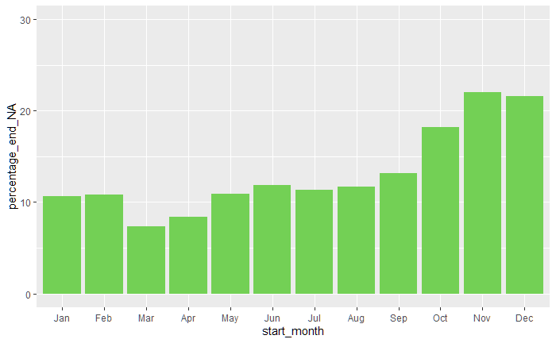

```r
bike_share %>%
  group_by(start_month) %>%
  summarize(percentage_end_NA = 100 * mean(is.na(end_station_id))) %>%
  ggplot(mapping = aes(x = start_month, y = percentage_end_NA)) +
  geom_col(fill = "#73D055FF") +
  coord_cartesian(ylim = c(0, 30))
```

The percentage of missing station information definitely increased in the last three months of the year.

Before we decide how to handle rides with missing station information, let’s take a look at the latitude and longitude data.

### Exploring - latitude and longitude

Fortunately, there are no missing values in the start latitude and longitude data, and very few in the end latitude and longitude data. Let’s look again at the percentages of missing values.

```r
bike_share %>%
  select(start_lat, start_lng, end_lat, end_lng) %>%
  map(is.na) %>%
  map_dbl(mean) * 100
```

```
 start_lat  start_lng    end_lat    end_lng
0.00000000 0.00000000 0.08526851 0.08526851
```

Less than 0.1 percent of end latitude and longitude data are missing.

Let’s check that end latitude is missing if and only if end longitude is.

```r
bike_share %>%
  filter(
    is.na(end_lat) & !is.na(end_lng) | !is.na(end_lat) & is.na(end_lng)
  ) %>%
  nrow()
```

```
[1] 0
```

There are no cases where only one of end latitude or longitude is missing.

Let’s check whether there are station IDs for the rides without end latitude and longitude.

```r
bike_share %>%
  filter(is.na(end_lat)) %>%
  distinct(end_station_id)
```

| end_station_id |
| --- |
| NA |

There are no end station IDs for these rides, and hence no end station names either. Let’s check the number of different start station IDs.

```r
bike_share %>%
  filter(is.na(end_lat)) %>%
  distinct(start_station_id) %>%
  count()
```

| n |
| --- |
| 614 |

There are 614 start station IDs. Let’s look for any pattern in the time distribution of these rides.

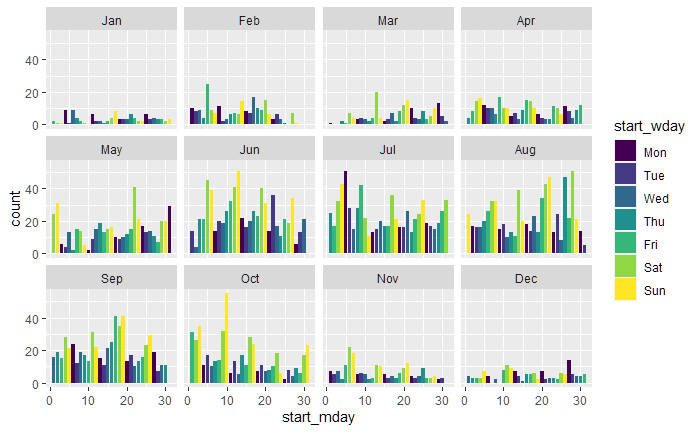

```r
bike_share %>%
  filter(is.na(end_lat)) %>%
  ggplot(mapping = aes(x = start_mday)) +
  geom_bar(mapping = aes(fill = start_wday)) +
  facet_wrap(~ start_month)
```

The rides are roughly distributed as rides are in general.

Let’s look at the type of bikes used for these rides.

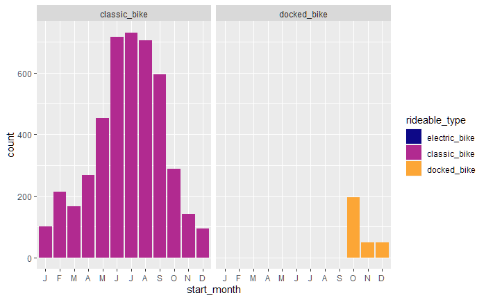

```r
bike_share %>%
  filter(is.na(end_lat)) %>%
  ggplot(mapping = aes(x = start_month)) +
  geom_bar(mapping = aes(fill = rideable_type)) +
  scale_x_discrete(labels = substr(levels(bike_share$start_month), 1, 1)) +
  scale_fill_viridis_d(option = "plasma", end = 0.8, drop = FALSE) +
  facet_wrap(~ rideable_type)
```

Only classic and docked bike rides have missing ride end location data. For docked bikes, this only happens in the last quarter of the year, which suggests that something changed in October.

There’s no indication that these rides should be removed, but we’ll need to keep them in mind when we do further analysis.

Let’s look at a summary of the latitude and longitude data.

```r
bike_share %>%
  select(start_lat, end_lat, start_lng, end_lng) %>%
  summary()
```

```
   start_lat        end_lat        start_lng         end_lng
 Min.   :41.64   Min.   :41.39   Min.   :-87.84   Min.   :-88.97
 1st Qu.:41.88   1st Qu.:41.88   1st Qu.:-87.66   1st Qu.:-87.66
 Median :41.90   Median :41.90   Median :-87.64   Median :-87.64
 Mean   :41.90   Mean   :41.90   Mean   :-87.65   Mean   :-87.65
 3rd Qu.:41.93   3rd Qu.:41.93   3rd Qu.:-87.63   3rd Qu.:-87.63
 Max.   :42.07   Max.   :42.17   Max.   :-87.52   Max.   :-87.49
                 NA's   :4770                     NA's   :4770
```

The quartiles and means for start and end locations match. But there’s a significant discrepancy in the minimum values for longitude. Let’s look for outliers in the latitude and longitude data.

First we’ll pivot the latitude and longitude data into a single table called lat_and_long, with all values in a single column. This will allow us to compare side-by-side box plots.

```r
lat_and_long <- bike_share %>%
  select(ends_with(c("lat", "lng"))) %>%
  pivot_longer(
    cols = ends_with(c("lat", "lng")),
    names_to = "name",
    values_to = "value"
  ) %>%
  filter(!is.na(value))

head(lat_and_long, n = 10)
```

| name | value |
| --- | --- |
| start_lat | 41.90034 |
| end_lat | 41.89000 |
| start_lng | -87.69674 |
| end_lng | -87.72000 |
| start_lat | 41.90033 |
| end_lat | 41.90000 |
| start_lng | -87.69671 |
| end_lng | -87.69000 |
| start_lat | 41.90031 |
| end_lat | 41.90000 |

Now we’ll compare start and end latitudes.

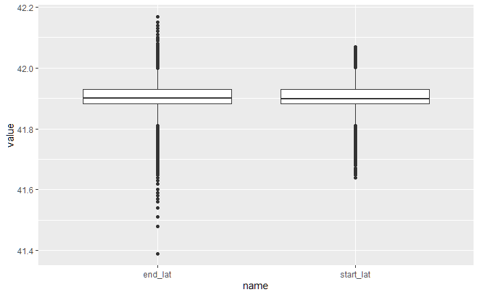

```r
lat_and_long %>%
  filter(name == "start_lat" | name == "end_lat") %>%
  ggplot(mapping = aes(x = name, y = value)) +
  geom_boxplot()
```

There are end latitudes well north and south of the range of start latitudes. Let’s get a count of rides with end latitude south of 41.65 or north of 42.07.

```r
bike_share %>%
  filter(end_lat < 41.65 | end_lat > 42.07) %>%
  nrow()
```

```
[1] 155
```

There are just 155 such rides. We won’t remove them from the data set. But in visualizations we’ll limit plots to latitudes from 41.65 to 42.07. This will prevent the outliers from causing the plots to zoom out too far.

Let’s look at the longitudes.

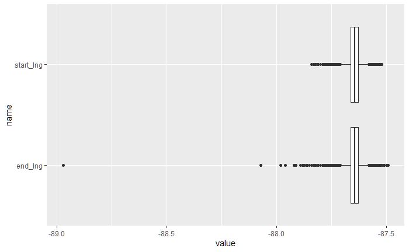

```r
lat_and_long %>%
  filter(name == "start_lng" | name == "end_lng") %>%
  ggplot(mapping = aes(x = value, y = name)) +
  geom_boxplot()
```

Let’s see how many rides have an end longitude west of -88.5.

```r
bike_share %>%
  filter(end_lng < -88.5) %>%
  nrow()
```

```
[1] 1
```

There’s only one, so we’ll remove it from the data set since it’s such an outlier.

```r
bike_share <- bike_share %>%
  filter(end_lng >= -88.5 | is.na(end_lng))
```

Let’s check the number of rows in the data set.

```r
nrow(bike_share)
```

```
[1] 5594092
```

The number of rows decreased by one to 5,594,092 as expected.

Let’s get a count of rides with end longitude east of -87.52 or west of -87.83.

```r
bike_share %>%
  filter(end_lng < -87.83 | end_lng > -87.52) %>%
  nrow()
```

```
[1] 83
```

There are 83 such rides. In visualizations we’ll use longitudes from -87.83 to -87.52.

We’ll create a variable called bike_coord to store the ggplot2 command which we’ll add to plots to set the coordinate limits.

```r
bike_coord <- coord_quickmap(xlim = c(-87.83, -87.52), ylim = c(41.65, 42.07))
```

Let’s plot all the start latitude and longitude data for a single month, October, to try to determine the difference between rides with and without start station IDs. We’ll make separate plots for the data with and without station IDs, and we’ll use the bike_coord command to set the limits of the plot.

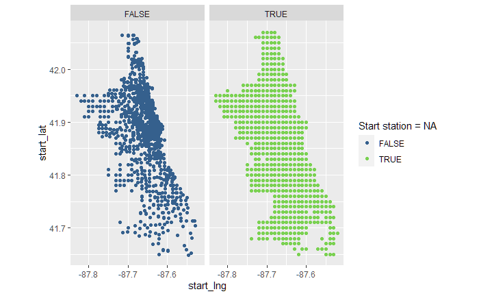

```r
bike_share %>%
  filter(start_month == "Oct") %>%
  ggplot(mapping = aes(x = start_lng, y = start_lat)) +
  geom_point(mapping = aes(color = is.na(start_station_id))) +
  facet_wrap(~ is.na(start_station_id)) +
  scale_color_viridis_d(
    begin = 0.3,
    end = 0.8,
    guide = guide_legend(title = "Start station = NA")
  ) +
  bike_coord
```

It’s clear from these plots that latitude and longitude data are only recorded to two decimal places when the station ID is missing, at least for October rides. Let’s verify that’s true for all rides with no station ID by rounding the values to two decimal places and comparing the rounded values to the raw values. We’ll check both start and end latitude and longitude data.

```r
bike_share %>%
  filter(is.na(start_station_id)) %>%
  transmute(
    start_lat_remainder = 10000000 * (start_lat - round(start_lat, 2)),
    start_lng_remainder = 10000000 * (start_lng - round(start_lng, 2))
  ) %>%
  summary()
```

```
 start_lat_remainder start_lng_remainder
 Min.   :0           Min.   :0
 1st Qu.:0           1st Qu.:0
 Median :0           Median :0
 Mean   :0           Mean   :0
 3rd Qu.:0           3rd Qu.:0
 Max.   :0           Max.   :0
```

```r
bike_share %>%
  filter(is.na(end_station_id)) %>%
  filter(!is.na(end_lat)) %>%
  transmute(
    end_lat_remainder = 10000000 * (end_lat - round(end_lat, 2)),
    end_lng_remainder = 10000000 * (end_lng - round(end_lng, 2))
  ) %>%
  summary()
```

```
 end_lat_remainder end_lng_remainder
 Min.   :0         Min.   :0
 1st Qu.:0         1st Qu.:0
 Median :0         Median :0
 Mean   :0         Mean   :0
 3rd Qu.:0         3rd Qu.:0
 Max.   :0         Max.   :0
```

We’ve confirmed that latitude and longitude are only recorded to two decimal places when there is no station ID.

Let’s zoom in on the stations at the top of the plot, with latitude in the range 42.00 to 42.10 and longitude in the range -87.75 to -87.65. We’ll put all points on the same plot, with color indicating whether the station ID is missing. We’ll use the alpha aesthetic so the points will be somewhat transparent.

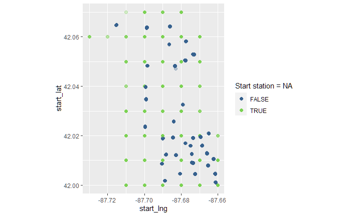

```r
bike_share %>%
  filter(start_month == "Oct") %>%
  filter(start_lat >= 42.00 & start_lat <= 42.10) %>%
  filter(start_lng >= -87.75 & start_lng <= -87.65) %>%
  ggplot(mapping = aes(x = start_lng, y = start_lat)) +
  geom_point(
    mapping = aes(color = is.na(start_station_id)),
    alpha = 0.3,
    size = 2
  ) +
  scale_color_viridis_d(
    begin = 0.3,
    end = 0.8,
    guide = guide_legend(
              title = "Start station = NA",
              override.aes = list(alpha = 1)
            )
  ) +
  coord_quickmap()
```

Let’s zoom in on another area. This time we’ll use May data, and we’ll use end stations instead of start stations.

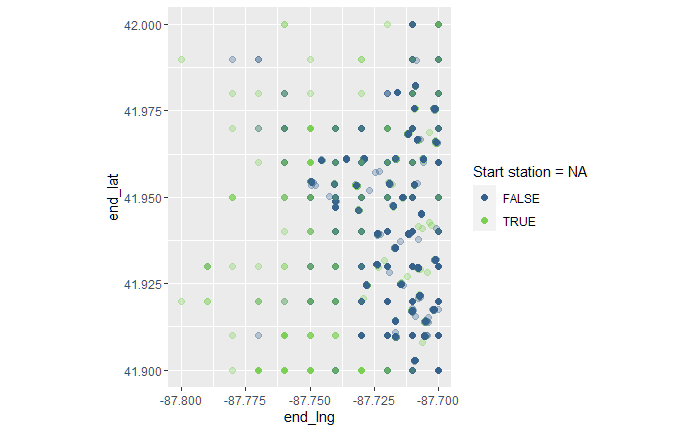

```r
bike_share %>%
  filter(start_month == "May") %>%
  filter(!is.na(end_lat)) %>%
  filter(end_lat >= 41.90 & end_lat <= 42.00) %>%
  filter(end_lng >= -87.80 & end_lng <= -87.70) %>%
  ggplot(mapping = aes(x = end_lng, y = end_lat)) +
  geom_point(
    mapping = aes(color = is.na(start_station_id)),
    alpha = 0.3,
    size = 2
  ) +
  scale_color_viridis_d(
    begin = 0.3,
    end = 0.8,
    guide = guide_legend(
              title = "Start station = NA",
              override.aes = list(alpha = 1)
            )
  ) +
  coord_quickmap()
```

This suggests that the bikes can be left at various places, perhaps at public bike racks. We’ll make that assumption, which means the rides with missing station IDs are probably rides which started or ended at a non-station location.

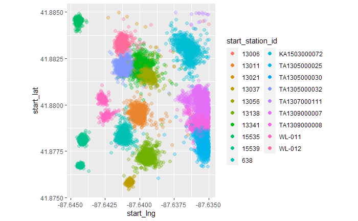

```r
bike_share %>%
  filter(start_quarter == 3) %>%
  filter(!is.na(start_station_id)) %>%
  filter(start_lat >= 41.875 & start_lat <= 41.885) %>%
  filter(start_lng >= -87.645 & start_lng <= -87.635) %>%
  ggplot(mapping = aes(x = start_lng, y = start_lat)) +
  geom_point(mapping = aes(color = start_station_id), alpha = 0.3, size = 2) +
  guides(color = guide_legend(override.aes = list(alpha = 1), ncol = 2)) +
  coord_quickmap()
```

There’s a lot of variation in the latitude and longitude data, as if the bikes are located near the station rather than at the station. Let’s see whether the type of bike has anything do to do with the variation.

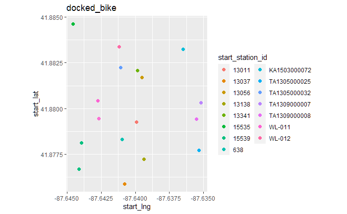

```r
bike_share %>%
  filter(start_quarter == 3) %>%
  filter(!is.na(start_station_id)) %>%
  filter(rideable_type == "docked_bike") %>%
  filter(start_lat >= 41.875 & start_lat <= 41.885) %>%
  filter(start_lng >= -87.645 & start_lng <= -87.635) %>%
  ggplot(mapping = aes(x = start_lng, y = start_lat)) +
  geom_point(mapping = aes(color = start_station_id), alpha = 0.3, size = 2) +
  guides(color = guide_legend(override.aes = list(alpha = 1), ncol = 2)) +
  ggtitle(label = "docked_bike") +
  coord_quickmap()
```

[figure not shown]

```r
bike_share %>%
  filter(start_quarter == 3) %>%
  filter(!is.na(start_station_id)) %>%
  filter(rideable_type == "classic_bike") %>%
  filter(start_lat >= 41.875 & start_lat <= 41.885) %>%
  filter(start_lng >= -87.645 & start_lng <= -87.635) %>%
  ggplot(mapping = aes(x = start_lng, y = start_lat)) +
  geom_point(mapping = aes(color = start_station_id), alpha = 0.3, size = 2) +
  guides(color = guide_legend(override.aes = list(alpha = 1), ncol = 2)) +
  ggtitle(label = "classic_bike") +
  coord_quickmap()
```

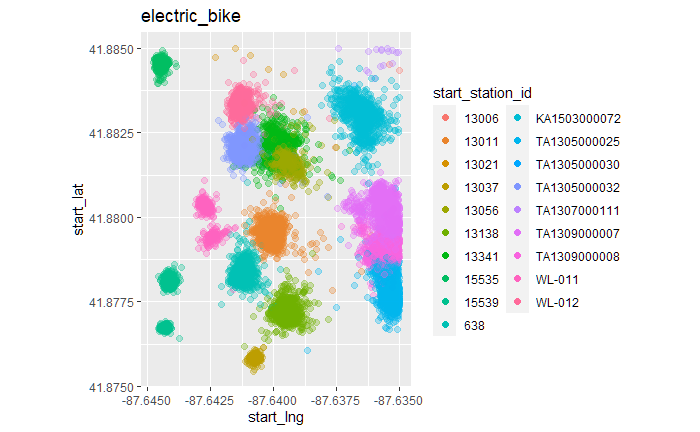

```r
bike_share %>%
  filter(start_quarter == 3) %>%
  filter(!is.na(start_station_id)) %>%
  filter(rideable_type == "electric_bike") %>%
  filter(start_lat >= 41.875 & start_lat <= 41.885) %>%
  filter(start_lng >= -87.645 & start_lng <= -87.635) %>%
  ggplot(mapping = aes(x = start_lng, y = start_lat)) +
  geom_point(mapping = aes(color = start_station_id), alpha = 0.3, size = 2) +
  guides(color = guide_legend(override.aes = list(alpha = 1), ncol = 2)) +
  ggtitle(label = "electric_bike") +
  coord_quickmap()
```

Clearly there’s something very different about electric bikes. It may be that they can be parked in the vicinity of a station, and the station ID is then determined from the latitude and longitude data.

Let’s try to figure out how bike type and station ID are related.

```r
bike_share %>%
  group_by(rideable_type) %>%
  summarize(
    percent_start_ID_NA = 100 * mean(is.na(start_station_id)),
    percent_end_ID_NA   = 100 * mean(is.na(end_station_id))
  )
```

| rideable_type | percent_start_ID_NA | percent_end_ID_NA |
| --- | --- | --- |
| electric_bike | 34.00408 | 35.92479412 |
| classic_bike | 0.00000 | 0.27805968 |
| docked_bike | 0.00000 | 0.09417644 |

About a third of electric bike rides have no start station ID, and likewise for end station ID. All classic and docked bikes have a start station ID, and only very small percentages are missing end station ID.

Let’s see what happens if we first remove the data that has no end latitude and longitude recorded.

```r
bike_share %>%
  filter(!is.na(end_lat)) %>%
  group_by(rideable_type) %>%
  summarize(
    percent_start_ID_NA = 100 * mean(is.na(start_station_id)),
    percent_end_ID_NA   = 100 * mean(is.na(end_station_id))
  )
```

| rideable_type | percent_start_ID_NA | percent_end_ID_NA |
| --- | --- | --- |
| electric_bike | 34.00408 | 35.9247941 |
| classic_bike | 0.00000 | 0.1405615 |
| docked_bike | 0.00000 | 0.0000000 |

We see that, as long as latitude and longitude data are recorded, rides with classic and docked bikes nearly always have a station ID. But electric bike rides often don’t have station IDs.

Let’s look again at our latitude and longitude data by focusing on bike types. First we’ll look at docked and classic bikes. We’ll use data from the third quarter.

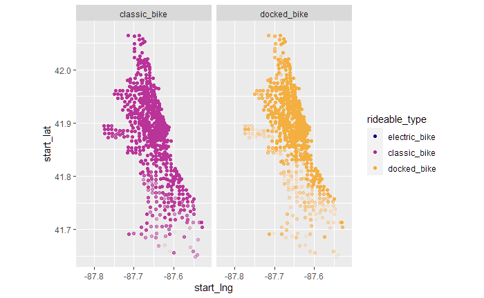

```r
bike_share %>%
  filter(start_quarter == 3) %>%
  filter(rideable_type != "electric_bike") %>%
  ggplot(mapping = aes(x = start_lng, y = start_lat)) +
  geom_point(mapping = aes(color = rideable_type), alpha = 0.05) +
  scale_color_viridis_d(option = "plasma", end = 0.8, drop = FALSE) +
  guides(color = guide_legend(override.aes = list(alpha = 1))) +
  facet_wrap(~ rideable_type) +
  bike_coord
```

There doesn’t appear to be much difference in the areas of usage for classic bikes and docked bikes, given that there are far fewer rides with docked bikes.

Let’s compare the electric bikes to the classic bikes.

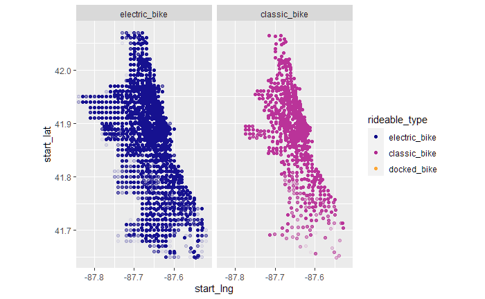

```r
bike_share %>%
  filter(start_quarter == 3) %>%
  filter(rideable_type != "docked_bike") %>%
  ggplot(mapping = aes(x = start_lng, y = start_lat)) +
  geom_point(mapping = aes(color = rideable_type), alpha = 0.05) +
  scale_color_viridis_d(option = "plasma", end = 0.8, drop = FALSE) +
  guides(color = guide_legend(override.aes = list(alpha = 1))) +
  facet_wrap(~ rideable_type) +
  bike_coord
```

We see that the start points for the electric bikes extend further west. The additional locations appear to be recorded to only two decimal places, so they likely correspond to locations with no station ID recorded. This is what we would expect, given the assumption that electric bikes can be obtained and parked in non-station locations.

Let’s compare the start and end location data for electric bikes.

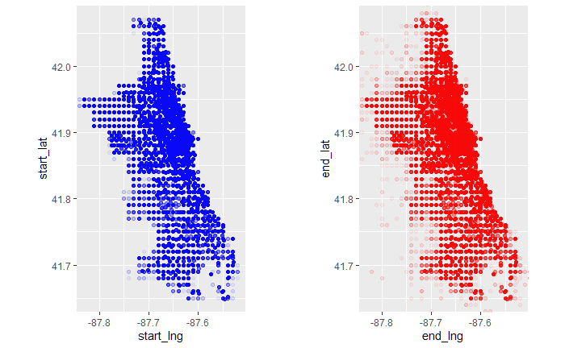

```r
start_plot <- bike_share %>%
  filter(start_quarter == 3) %>%
  filter(rideable_type == "electric_bike") %>%
  ggplot(mapping = aes(x = start_lng, y = start_lat)) +
  geom_point(color = "blue", alpha = 0.05) +
  bike_coord

end_plot <- bike_share %>%
  filter(start_quarter == 3) %>%
  filter(rideable_type == "electric_bike") %>%
  ggplot(mapping = aes(x = end_lng, y = end_lat)) +
  geom_point(color = "red", alpha = 0.05) +
  bike_coord

grid.arrange(start_plot, end_plot, ncol = 2)
```

There are a more locations where rides end in the outskirts of the city, but overall there’s not much difference in the distributions of start and end locations.

Let’s look for any seasonal variation in ride locations. For this we’ll round the latitude and longitude data to two decimal places, and use color to represent the percentage of rides that started at each location in each quarter

We’ll make separate plots for each bike type. First the docked bikes.

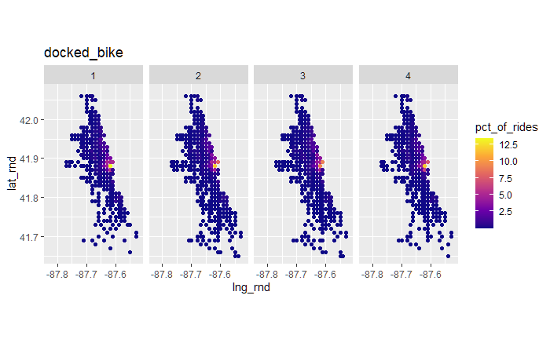

```r
bike_share %>%
  filter(rideable_type == "docked_bike") %>%
  mutate(
    lng_rnd = round(start_lng, 2),
    lat_rnd = round(start_lat, 2)
  ) %>%
  group_by(start_quarter) %>%
  mutate(quarter_rides = n()) %>%
  group_by(lng_rnd, lat_rnd, start_quarter) %>%
  summarize(pct_of_rides = 100 * n()/ quarter_rides, .groups = "keep") %>%
  ggplot(mapping = aes(x = lng_rnd, y = lat_rnd)) +
  geom_point(mapping = aes(color = pct_of_rides)) +
  scale_colour_viridis_c(option = "plasma") +
  facet_wrap(~ start_quarter, nrow = 1) +
  ggtitle(label = "docked_bike") +
  bike_coord
```

For docked bikes, the percentage of bike use by location doesn’t vary much over the year

Let’s look at the classic bikes.

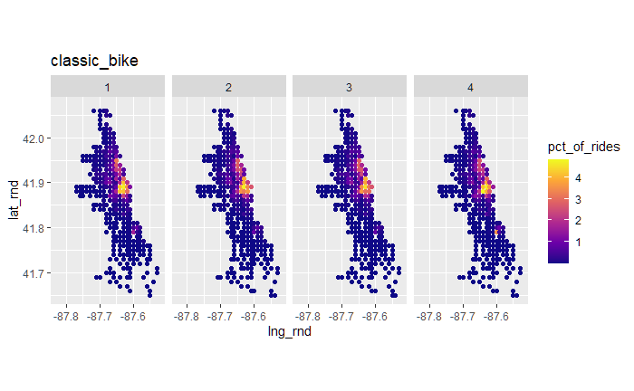

```r
bike_share %>%
  filter(rideable_type == "classic_bike") %>%
  mutate(
    lng_rnd = round(start_lng, 2),
    lat_rnd = round(start_lat, 2)
  ) %>%
  group_by(start_quarter) %>%
  mutate(quarter_rides = n()) %>%
  group_by(lng_rnd, lat_rnd, start_quarter) %>%
  summarize(pct_of_rides = 100 * n()/ quarter_rides, .groups = "keep") %>%
  ggplot(mapping = aes(x = lng_rnd, y = lat_rnd)) +
  geom_point(mapping = aes(color = pct_of_rides)) +
  scale_colour_viridis_c(option = "plasma") +
  facet_wrap(~ start_quarter, nrow = 1) +
  ggtitle(label = "classic_bike") +
  bike_coord
```

For classic bikes, the pattern is fairly constant throughout the year. But the areas of heavy use are more extensive than for docked bikes.

Let’s look at the electric bikes.

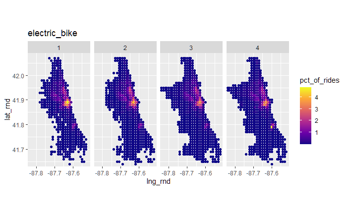

```r
bike_share %>%
  filter(rideable_type == "electric_bike") %>%
  mutate(
    lng_rnd = round(start_lng, 2),
    lat_rnd = round(start_lat, 2)
  ) %>%
  group_by(start_quarter) %>%
  mutate(quarter_rides = n()) %>%
  group_by(lng_rnd, lat_rnd, start_quarter) %>%
  summarize(pct_of_rides = 100 * n()/ quarter_rides, .groups = "keep") %>%
  ggplot(mapping = aes(x = lng_rnd, y = lat_rnd)) +
  geom_point(mapping = aes(color = pct_of_rides)) +
 scale_colour_viridis_c(option = "plasma") +
  facet_wrap(~ start_quarter, nrow = 1) +
  ggtitle(label = "electric_bike") +
  bike_coord
```

The electric bikes also have a fairly consistent pattern through the year. But as the year progressed, there were rides starting at points further west, as if there had been an expansion of the areas in which electric bikes were available.

Let’s see whether day of the week affects where rides start.

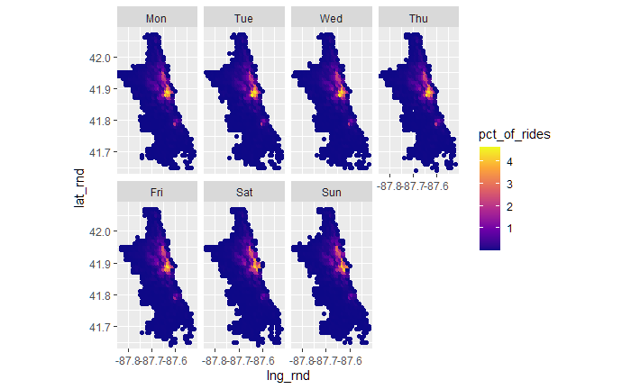

```r
bike_share %>%
  mutate(
    lng_rnd = round(start_lng, 2),
    lat_rnd = round(start_lat, 2)
  ) %>%
  group_by(start_wday) %>%
  mutate(wday_rides = n()) %>%
  group_by(lng_rnd, lat_rnd, start_wday) %>%
  summarize(pct_of_rides = 100 * n()/ wday_rides, .groups = "keep") %>%
  ggplot(mapping = aes(x = lng_rnd, y = lat_rnd)) +
  geom_point(mapping = aes(color = pct_of_rides)) +
  scale_colour_viridis_c(option = "plasma") +
  facet_wrap(~ start_wday, nrow = 2) +
  bike_coord
```

The start locations of rides don’t appear to vary much by day of the week.

Let’s compare locations at different hours of the day. We’ll look at the 8 a.m., 12 noon, 5 p.m., and 9 p.m. hours.

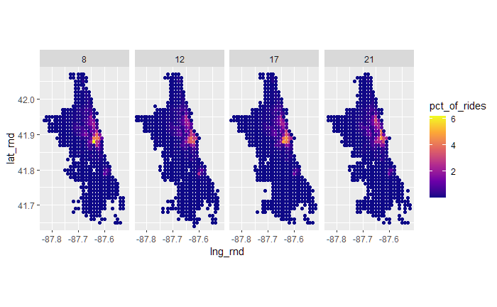

```r
bike_share %>%
  filter(start_hour %in% c(8, 12, 17, 21)) %>%
  mutate(
    lng_rnd = round(start_lng, 2),
    lat_rnd = round(start_lat, 2)
  ) %>%
  group_by(start_hour) %>%
  mutate(hour_rides = n()) %>%
  group_by(lng_rnd, lat_rnd, start_hour) %>%
  summarize(pct_of_rides = 100 * n()/ hour_rides, .groups = "keep") %>%
  ggplot(mapping = aes(x = lng_rnd, y = lat_rnd)) +
  geom_point(mapping = aes(color = pct_of_rides)) +
  scale_colour_viridis_c(option = "plasma") +
  facet_wrap(~ start_hour, nrow = 1) +
  bike_coord
```

Nothing appears unusual here.

Let’s check whether the location data gives us any information about the rides with very short or very long duration.

First we’ll plot the locations of rides with duration less than 30 seconds.

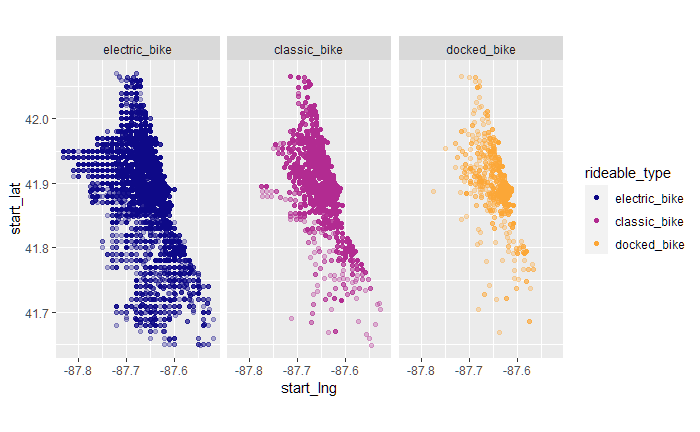

```r
bike_share %>%
  filter(ride_duration < 30) %>%
  ggplot(mapping = aes(x = start_lng, y = start_lat)) +
  geom_point(mapping = aes(color = rideable_type), alpha = 0.3) +
  scale_color_viridis_d(option = "plasma", end = 0.8, drop = FALSE) +
  guides(color = guide_legend(override.aes = list(alpha = 1))) +
  facet_wrap(~ rideable_type, nrow = 1) +
  bike_coord
```

Location doesn’t appear to have anything to do with short ride duration. Let’s check the rides that last more than a day.

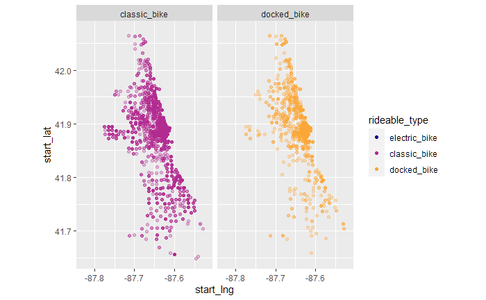

```r
bike_share %>%
  filter(ride_duration > 3600 * 24) %>%
  ggplot(mapping = aes(x = start_lng, y = start_lat)) +
  geom_point(mapping = aes(color = rideable_type), alpha = 0.3) +
  scale_color_viridis_d(option = "plasma", end = 0.8, drop = FALSE) +
  guides(color = guide_legend(override.aes = list(alpha = 1))) +
  facet_wrap(~ rideable_type, nrow = 1) +
  bike_coord
```

Location doesn’t appear to have anything to do with long ride duration either.

### Exploring - ride displacement

Finally, let’s look at the ride displacement values.

```r
summary(bike_share$ride_displacement)
```

```
   Min. 1st Qu.  Median    Mean 3rd Qu.    Max.    NA's
  0.000   0.010   0.017   0.022   0.030   0.359    4770
```

These values don’t represent an actual distance for the ride. They simply give a relative value for how far apart the start and end locations are, based on treating the latitude and longitude as points on a flat surface. A ride that lasted hours will have a ride_displacement value of zero if it ended at the same location that it started.

Let’s look at a histogram of the data.

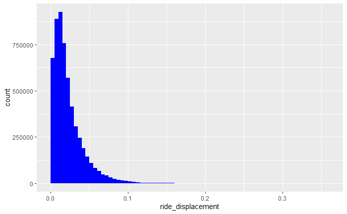

```r
bike_share %>%
  filter(!is.na(ride_displacement)) %>%
  ggplot(mapping = aes(x = ride_displacement)) +
  geom_histogram(binwidth = 0.005, boundary = 0, fill = "blue")
```

The displacement distribution is similar to that of ride duration. Let’s focus on the displacements that are between 0 and 0.1.

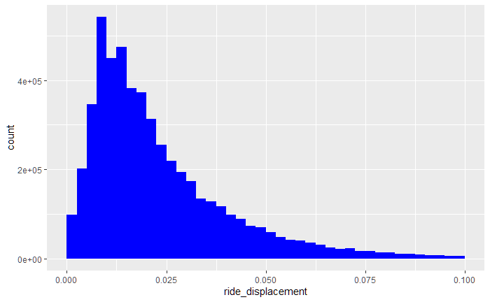

```r
bike_share %>%
  filter(!is.na(ride_displacement)) %>%
  filter(ride_displacement > 0 & ride_displacement < 0.1) %>%
  ggplot(mapping = aes(x = ride_displacement)) +
  geom_histogram(binwidth = 0.0025, boundary = 0, fill = "blue")
```

There’s a peak around 0.010, with a long tail to the right.

Let’s check the percentage of rides that end at the same location they start, by month. Since electric bikes have some variation in the way their locations are recorded, we’ll check for displacements less than 0.001

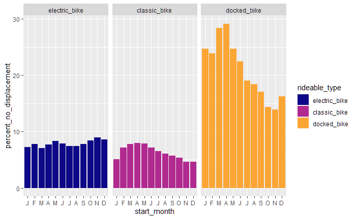

```r
bike_share %>%
  filter(!is.na(ride_displacement)) %>%
  group_by(rideable_type, start_month) %>%
  summarize(
    percent_no_displacement = 100 * mean(ride_displacement < 0.001),
    .groups = "keep"
  ) %>%
  ggplot(mapping = aes(x = start_month, y = percent_no_displacement)) +
  geom_col(mapping = aes(fill = rideable_type)) +
  scale_fill_viridis_d(option = "plasma", end = 0.8, drop = FALSE) +
  scale_x_discrete(labels = substr(levels(bike_share$start_month), 1, 1)) +
  facet_wrap(~ rideable_type)
```

Docked bikes are returned to the start location at higher percentages than electric or classic bikes are. Also, the percentages of classic and docked bikes with no displacement fell noticeably as the year progressed.

Let’s look at monthly median displacements, by bike type.

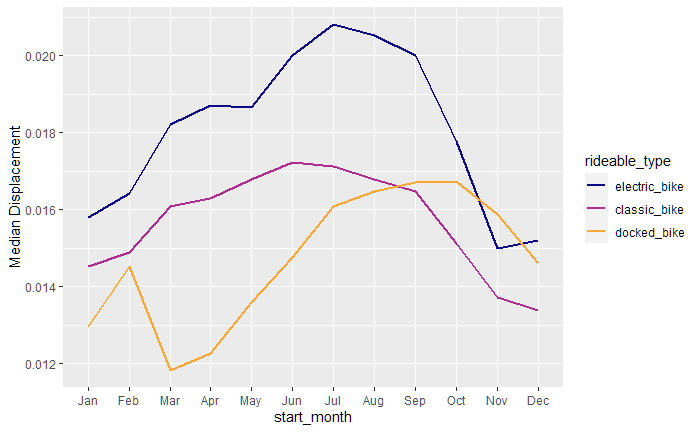

```r
bike_share %>%
  filter(!is.na(ride_displacement)) %>%
  group_by(rideable_type, start_month) %>%
  summarize(med_displ = median(ride_displacement), .groups = "keep") %>%
  ggplot(mapping = aes(x = start_month, y = med_displ, group = rideable_type)) +
  geom_line(mapping = aes(color = rideable_type), size = 1) +
  scale_color_viridis_d(option = "plasma", end = 0.8, drop = FALSE) +
  ylab(label = "Median Displacement")
```

The median displacement peaks in the summer months for electric and classic bikes, and is consistently higher for electric than for classic bikes. For docked bikes, the median displacement dropped to a low in March, then increased to a peak in October. The graph suggests some sort of change in the way docked bikes were used in the later half of the year. But the very low volumes of docked bike rides in the winter months may have a large effect on these median values.

Let’s look at median displacement by day of the week. We’ll look at each quarter.

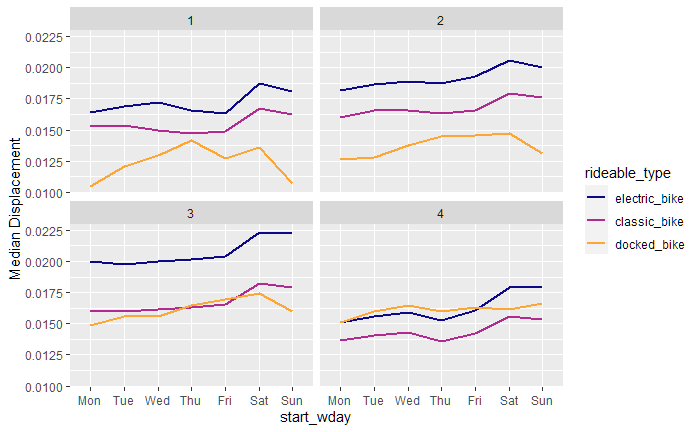

```r
bike_share %>%
  filter(!is.na(ride_displacement)) %>%
  group_by(rideable_type, start_wday, start_quarter) %>%
  summarize(med_displ = median(ride_displacement), .groups = "keep") %>%
  ggplot(mapping = aes(x = start_wday, y = med_displ, group = rideable_type)) +
  geom_line(mapping = aes(color = rideable_type), size = 1) +
  scale_color_viridis_d(option = "plasma", end = 0.8, drop = FALSE) +
  ylab(label = "Median Displacement") +
  facet_wrap(~ start_quarter)
```

The displacements generally increase on weekends for electric and classic bikes, but not for docked bikes.

Let’s check whether hour of the day affects displacement

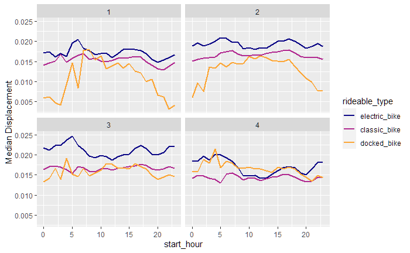

```r
bike_share %>%
  filter(!is.na(ride_displacement)) %>%
  group_by(rideable_type, start_hour, start_quarter) %>%
  summarize(med_displ = median(ride_displacement), .groups = "keep") %>%
  ggplot(mapping = aes(x = start_hour, y = med_displ, group = rideable_type)) +
  geom_line(mapping = aes(color = rideable_type), size = 1) +
  scale_color_viridis_d(option = "plasma", end = 0.8, drop = FALSE) +
  ylab(label = "Median Displacement") +
  facet_wrap(~ start_quarter)
```

The hour doesn’t seem to have much effect on displacement except for docked bikes in the first half of the year. In the first half of the year, the displacements for docked bikes were lower at night, but in the second half of the year the hour doesn’t have much effect on displacement.

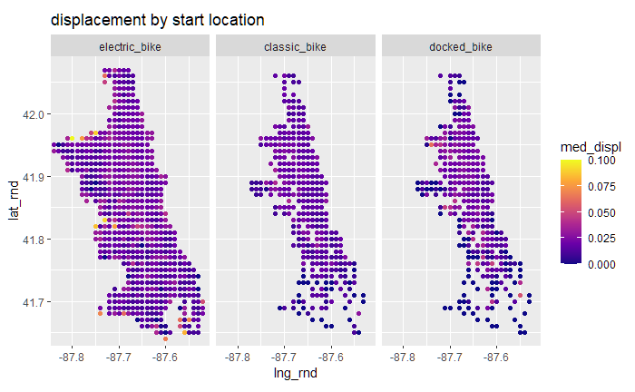

```r
bike_share %>%
  filter(!is.na(ride_displacement)) %>%
  filter(start_quarter %in% c(3, 4)) %>%
  mutate(
    lng_rnd = round(start_lng, 2),
    lat_rnd = round(start_lat, 2)
  ) %>%
  group_by(lng_rnd, lat_rnd, rideable_type) %>%
  summarize(med_displ = median(ride_displacement), .groups = "keep") %>%
  ggplot(mapping = aes(x = lng_rnd, y = lat_rnd)) +
  geom_point(mapping = aes(color = med_displ)) +
  scale_colour_viridis_c(option = "plasma") +
  facet_wrap(~ rideable_type) +
  ggtitle(label = "displacement by start location") +
  bike_coord
```

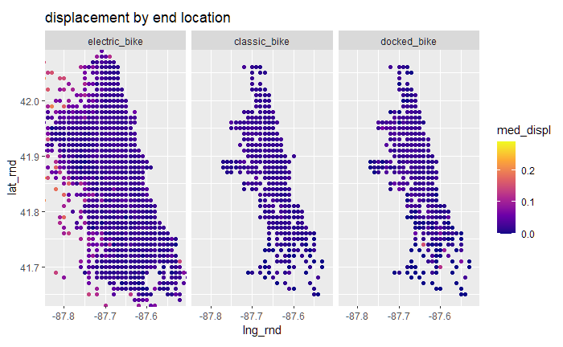

```r
bike_share %>%
  filter(!is.na(ride_displacement)) %>%
  filter(start_quarter %in% c(3, 4)) %>%
  mutate(
    lng_rnd = round(end_lng, 2),
    lat_rnd = round(end_lat, 2)
  ) %>%
  group_by(lng_rnd, lat_rnd, rideable_type) %>%
  summarize(med_displ = median(ride_displacement), .groups = "keep") %>%
  ggplot(mapping = aes(x = lng_rnd, y = lat_rnd)) +
  geom_point(mapping = aes(color = med_displ)) +
  scale_colour_viridis_c(option = "plasma") +
  facet_wrap(~ rideable_type) +
  ggtitle(label = "displacement by end location") +
  bike_coord
```

Electric bikes have the greatest median displacements, as expected. In general the greatest displacements are associated with rides that start or end far from the city center. In particular, the greatest displacements are for rides at end locations in the far west of the city, at locations that aren’t seen on the graph of start locations. Note the difference in the values of the color scales for the displacement in the two graphs.

Let’s take a look at whether there’s any correlation between ride duration and ride displacement.

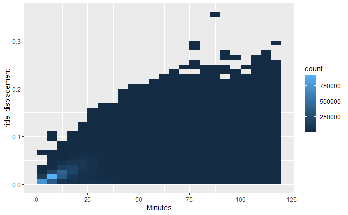

```r
bike_share %>%
  filter(!is.na(ride_displacement)) %>%
  filter(ride_duration < 2 * 3600) %>%
  ggplot(mapping = aes(x = ride_duration / 60, y = ride_displacement)) +
  geom_bin2d(binwidth = c(5, 0.01)) +
  xlab("Minutes")
```

As expected, there’s some correlation but there are a lot of rides with high duration and low displacement.

This concludes the data preparation and exploration phase of this project.